# Interactions

## Interactions and qualitative variables

### Chapter 5, RABE

- Most variables we have looked at so far were continuous: `height`, `rating`, etc.
- In many situations, we record a categorical variable: `sex` or `gender`, `state`, `country`, etc.
- We call these variables *categorical* or *qualtitative* variables. In `R`, these are referred to as `factors`.
- For our purposes, we want to answer: **How do we include this in our model?**

This will eventually lead us to the notion of *interactions* and some special regression models called *ANOVA* (analysis of variance) models.

```r
options(repr.plot.width=4, repr.plot.height=4)
```

### Two-sample problem

In some sense, we have already seen a regression model with categorical variables: the two-sample model.

- Two sample problem with equal variances: suppose $Z_j \sim N(\mu_1, \sigma^2), 1 \leq j \leq m$ and $W_j \sim N(\mu_2, \sigma^2), 1 \leq j \leq n $.
- For $1 \leq i \leq n$, let $$X_i = \begin{cases} 1 & 1 \leq i \leq m \\ 0 & \text{otherwise.} \end{cases}$$

The design matrix and response look like $$ Y_{(n+m) \times 1} = \begin{pmatrix} Z_1 \\ \vdots \\ Z_m \\ W_1 \\ \vdots \\ W_n \\ \end{pmatrix}, \qquad X_{(n+m) \times 2} = \begin{pmatrix} 1 & 1 \\ \vdots & \vdots \\ 1 & 1 \\ 1 & 0 \\ \vdots & \vdots \\ 1 & 0 \end{pmatrix}$$

### Salary example

In this example, we have data on salaries of employees in IT (several years ago?) based on their years of experience, their education level and whether or not they are management.

- Outcome: `S`, salaries for IT staff in a corporation.
- Predictors:
  - `X`, experience (years)
  - `E`, education (1=Bachelor’s, 2=Master’s, 3=Ph.D)
  - `M`, management (1=management, 0=not management)

```r
url = 'http://stats191.stanford.edu/data/salary.table'
salary.table <- read.table(url, header=T)
salary.table$E <- factor(salary.table$E)
salary.table$M <- factor(salary.table$M)
```

Let's take a quick look at how `R` treats a `factor`

```r
str(salary.table$E)
```

```
 Factor w/ 3 levels "1","2","3": 1 3 3 2 3 2 2 1 3 2 ...
```

Let's take a look at the data. We will use triangles for management, diamonds for non-management red for education=1, green for education=2 and blue for education=3.

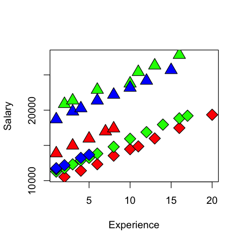

```r
plot(salary.table$X, salary.table$S, type='n', xlab='Experience', ylab='Salary')
colors <- c('red', 'green', 'blue')
symbols <- c(23,24)
for (i in 1:3) {
    for (j in 0:1) {
        subset <- as.logical((salary.table$E == i) * (salary.table$M == j))
        points(salary.table$X[subset], salary.table$S[subset], pch=symbols[j+1], bg=colors[i], cex=2)
    }
}
```

## Effect of experience

In these pictures, the slope of each line seems to be about the same. How might we estimate it?

### One solution is *stratification*.

- Make six separate models (one for each combination of `E` and `M`) and estimate the slope.
- Combining them: we could average them?
- We have few degrees of freedom in each group.

### Or, use *qualitative* variables

- IF it is reasonable to assume that $\sigma^2$ is constant for each observation.
- THEN, we can incorporate all observations into 1 model.

$$S_i = \beta_0 + \beta_1 X_i + \beta_2 E_{i2} + \beta_3 E_{i3} + \beta_4 M_i + \varepsilon_i$$

Above, the variables are:

- $$ E_{i2} = \begin{cases} 1 & \text{if $E_i$=2} \\ 0 & \text{otherwise.} \end{cases} $$
- $$ E_{i3} = \begin{cases} 1 & \text{if $E_i$=3} \\ 0 & \text{otherwise.} \end{cases} $$

### Notes

- Although $E$ has 3 levels, we only added 2 variables to the model. In a sense, this is because `(Intercept)` (i.e. $\beta_0$) absorbs one level.
- If we added three variables then the columns of design matrix would be linearly dependent so we would not have a unique least squares solution.
- Assumes $\beta_1$ – effect of experience is the same in all groups, unlike when we fit the model separately. This may or may not be reasonable.

```r
salary.lm <- lm(S ~ E + M + X, salary.table)
summary(salary.lm)
```

```
Call:
lm(formula = S ~ E + M + X, data = salary.table)

Residuals:
     Min       1Q   Median       3Q      Max
-1884.60  -653.60    22.23   844.85  1716.47

Coefficients:
            Estimate Std. Error t value Pr(>|t|)
(Intercept)  8035.60     386.69  20.781  < 2e-16 ***
E2           3144.04     361.97   8.686 7.73e-11 ***
E3           2996.21     411.75   7.277 6.72e-09 ***
M1           6883.53     313.92  21.928  < 2e-16 ***
X             546.18      30.52  17.896  < 2e-16 ***
---
Signif. codes:  0 ‘***’ 0.001 ‘**’ 0.01 ‘*’ 0.05 ‘.’ 0.1 ‘ ’ 1

Residual standard error: 1027 on 41 degrees of freedom
Multiple R-squared:  0.9568,	Adjusted R-squared:  0.9525
F-statistic: 226.8 on 4 and 41 DF,  p-value: < 2.2e-16
```

Now, let's take a look at our design matrix

```r
head(model.matrix(salary.lm))
```

|  | (Intercept) | E2 | E3 | M1 | X |
| --- | --- | --- | --- | --- | --- |
| 1 | 1 | 0 | 0 | 1 | 1 |
| 2 | 1 | 0 | 1 | 0 | 1 |
| 3 | 1 | 0 | 1 | 1 | 1 |
| 4 | 1 | 1 | 0 | 0 | 1 |
| 5 | 1 | 0 | 1 | 0 | 1 |
| 6 | 1 | 1 | 0 | 1 | 2 |

Comparing to our actual data, we can understand how the columns above were formed. They were formed just as we had defined them above.

```r
head(model.frame(salary.lm))
```

| S | E | M | X |
| --- | --- | --- | --- |
| 13876 | 1 | 1 | 1 |
| 11608 | 3 | 0 | 1 |
| 18701 | 3 | 1 | 1 |
| 11283 | 2 | 0 | 1 |
| 11767 | 3 | 0 | 1 |
| 20872 | 2 | 1 | 2 |

### Effect of experience

- Our model has enforced the constraint the $\beta_1$ is the same within each group.
- Graphically, this seems OK, but how can we test this?
- We could fit a model with different slopes in each group, but keeping as many degrees of freedom as we can.
- This model has *interactions* in it: the effect of experience depends on what level of education you have.

### Interaction between experience and education

- Model: $$\begin{aligned} S_i &= \beta_0 + \beta_1 X_i + \beta_2 E_{i2} + \beta_3 E_{i3} +\ \beta_4 M_i \\ & \qquad + \beta_5 E_{i2} X_i + \beta_6 E_{i3} X_i + \varepsilon_i. \end{aligned}$$
- What is the regression function within each group?
- Note that we took each column corresponding to education and multiplied it by the column for experience to get two new predictors.
- To test whether the slope is the same in each group we would just test $H_0:\beta_5 = \beta_6=0$.
- Based on figure, we expect not to reject $H_0$.

```r
model_XE = lm(S~ E + M + X + X:E, salary.table)
summary(model_XE)
```

```
Call:
lm(formula = S ~ E + M + X + X:E, data = salary.table)

Residuals:
     Min       1Q   Median       3Q      Max
-2013.04  -634.68   -16.71   615.66  2014.14

Coefficients:
            Estimate Std. Error t value Pr(>|t|)
(Intercept)  7256.28     549.49  13.205 5.65e-16 ***
E2           4172.50     674.97   6.182 2.90e-07 ***
E3           3946.36     686.69   5.747 1.16e-06 ***
M1           7102.45     333.44  21.300  < 2e-16 ***
X             632.29      53.19  11.888 1.53e-14 ***
E2:X         -125.51      69.86  -1.797   0.0801 .
E3:X         -141.27      89.28  -1.582   0.1216
---
Signif. codes:  0 ‘***’ 0.001 ‘**’ 0.01 ‘*’ 0.05 ‘.’ 0.1 ‘ ’ 1

Residual standard error: 1005 on 39 degrees of freedom
Multiple R-squared:  0.9606,	Adjusted R-squared:  0.9546
F-statistic: 158.6 on 6 and 39 DF,  p-value: < 2.2e-16
```

```r
anova(salary.lm, model_XE)
```

| Res.Df | RSS | Df | Sum of Sq | F | Pr(>F) |
| --- | --- | --- | --- | --- | --- |
| 41 | 43280719 | NA | NA | NA | NA |
| 39 | 39410680 | 2 | 3870040 | 1.914856 | 0.1609642 |

The notation `X:E` denotes an *interaction*. Generally, `R` will take the columns added for `E` and the columns added for `X` and add their elementwise product (Hadamard product) to the design matr.x

Let's look at our design matrix again to be sure we understand what model was fit.

```r
model.matrix(model_XE)[10:20,]
```

|  | (Intercept) | E2 | E3 | M1 | X | E2:X | E3:X |
| --- | --- | --- | --- | --- | --- | --- | --- |
| 10 | 1 | 1 | 0 | 0 | 3 | 3 | 0 |
| 11 | 1 | 0 | 0 | 1 | 3 | 0 | 0 |
| 12 | 1 | 1 | 0 | 1 | 3 | 3 | 0 |
| 13 | 1 | 0 | 1 | 1 | 3 | 0 | 3 |
| 14 | 1 | 0 | 0 | 0 | 4 | 0 | 0 |
| 15 | 1 | 0 | 1 | 1 | 4 | 0 | 4 |
| 16 | 1 | 0 | 1 | 0 | 4 | 0 | 4 |
| 17 | 1 | 1 | 0 | 0 | 4 | 4 | 0 |
| 18 | 1 | 1 | 0 | 0 | 5 | 5 | 0 |
| 19 | 1 | 0 | 1 | 0 | 5 | 0 | 5 |
| 20 | 1 | 0 | 0 | 1 | 5 | 0 | 0 |

## Remember, it's still a model (i.e. a plane)

[figure not shown]

### Interaction between management and education

- We can also test for interactions between qualitative variables.
- In our plot, note that Master's in management make more than PhD's in management, but this difference disappears in non-management.
- This means the effect of education is different in the two management levels. This is evidence of an *interaction*.
- To see this, we plot the residuals within groups separately.

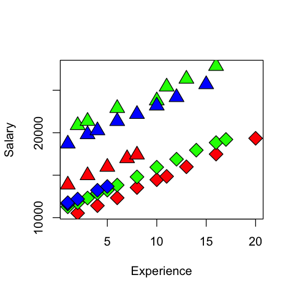

```r
plot(salary.table$X, salary.table$S, type='n', xlab='Experience', ylab='Salary')
colors <- c('red', 'green', 'blue')
symbols <- c(23,24)
for (i in 1:3) {
    for (j in 0:1) {
        subset <- as.logical((salary.table$E == i) * (salary.table$M == j))
        points(salary.table$X[subset], salary.table$S[subset], pch=symbols[j+1], bg=colors[i], cex=2)
    }
}
```

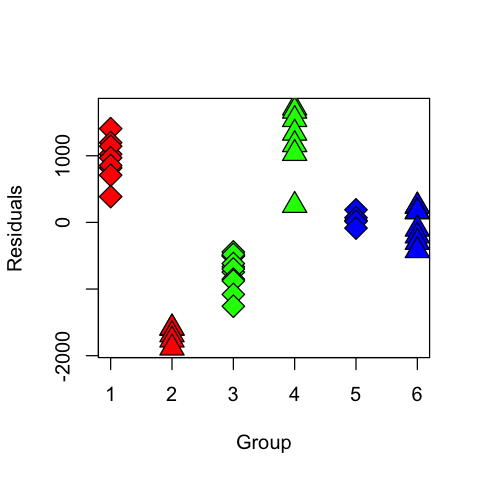

```r
r = resid(salary.lm)
k = 1
plot(salary.table$X, r, xlim=c(1,6), type='n', xlab='Group', ylab='Residuals')
for (i in 1:3) {
    for (j in 0:1) {
        subset <- as.logical((salary.table$E == i) * (salary.table$M == j))
        points(rep(k, length(r[subset])), r[subset], pch=symbols[j+1], bg=colors[i], cex=2)
        k = k+1
    }
}
```

`R` has a special plot that can help visualize this effect, called an `interaction.plot`.

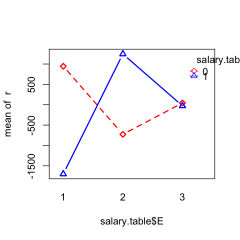

```r
interaction.plot(salary.table$E, salary.table$M, r, type='b', col=c('red',
                'blue'), lwd=2, pch=c(23,24))
```

### Interaction between management and education

- Based on figure, we expect an interaction effect.
- Fit model $$\begin{aligned} S_i &= \beta_0 + \beta_1 X_i + \beta_2 E_{i2} + \beta_3 E_{i3} +\ \beta_4 M_i \\ & \qquad + \beta_5 E_{i2} M_i + \beta_6 E_{i3} M_i + \varepsilon_i. \end{aligned}$$
- Again, testing for interaction is testing $H_0:\beta_5=\beta_6=0.$
- What is the regression function within each group?

```r
model_EM = lm(S ~ X + E:M + E + M, salary.table)
summary(model_EM)
```

```
Call:
lm(formula = S ~ X + E:M + E + M, data = salary.table)

Residuals:
    Min      1Q  Median      3Q     Max
-928.13  -46.21   24.33   65.88  204.89

Coefficients:
            Estimate Std. Error t value Pr(>|t|)
(Intercept) 9472.685     80.344  117.90   <2e-16 ***
X            496.987      5.566   89.28   <2e-16 ***
E2          1381.671     77.319   17.87   <2e-16 ***
E3          1730.748    105.334   16.43   <2e-16 ***
M1          3981.377    101.175   39.35   <2e-16 ***
E2:M1       4902.523    131.359   37.32   <2e-16 ***
E3:M1       3066.035    149.330   20.53   <2e-16 ***
---
Signif. codes:  0 ‘***’ 0.001 ‘**’ 0.01 ‘*’ 0.05 ‘.’ 0.1 ‘ ’ 1

Residual standard error: 173.8 on 39 degrees of freedom
Multiple R-squared:  0.9988,	Adjusted R-squared:  0.9986
F-statistic:  5517 on 6 and 39 DF,  p-value: < 2.2e-16
```

```r
anova(salary.lm, model_EM)
```

| Res.Df | RSS | Df | Sum of Sq | F | Pr(>F) |
| --- | --- | --- | --- | --- | --- |
| 41 | 43280719 | NA | NA | NA | NA |
| 39 | 1178168 | 2 | 42102552 | 696.8445 | 3.025504e-31 |

Let's look at our design matrix again to be sure we understand what model was fit.

```r
head(model.matrix(model_EM))
```

|  | (Intercept) | X | E2 | E3 | M1 | E2:M1 | E3:M1 |
| --- | --- | --- | --- | --- | --- | --- | --- |
| 1 | 1 | 1 | 0 | 0 | 1 | 0 | 0 |
| 2 | 1 | 1 | 0 | 1 | 0 | 0 | 0 |
| 3 | 1 | 1 | 0 | 1 | 1 | 0 | 1 |
| 4 | 1 | 1 | 1 | 0 | 0 | 0 | 0 |
| 5 | 1 | 1 | 0 | 1 | 0 | 0 | 0 |
| 6 | 1 | 2 | 1 | 0 | 1 | 1 | 0 |

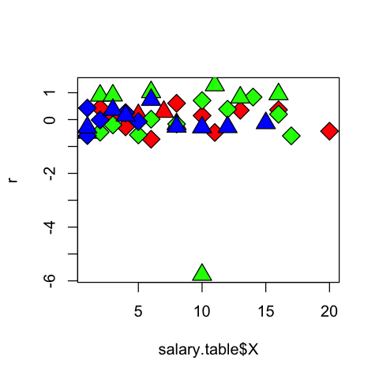

```r
r = rstandard(model_EM)
plot(salary.table$X, r, type='n')
for (i in 1:3) {
    for (j in 0:1) {
        subset <- as.logical((salary.table$E == i) * (salary.table$M == j))
        points(salary.table$X[subset], r[subset], pch=symbols[j+1], bg=colors[i], cex=2)
    }
}
```

One observation seems to be an outlier.

```r
library(car)
outlierTest(model_EM)
```

```
    rstudent unadjusted p-value Bonferonni p
33 -14.95083         1.6769e-17    7.714e-16
```

Let's refit our model to see that our conclusions are not vastly different.

```r
subs33 = c(1:length(salary.table$S))[-33]
salary.lm33 = lm(S ~ E + X + M, data=salary.table, subset=subs33)
model_EM33 = lm(S ~ E + X + E:M + M, data=salary.table, subset=subs33)
anova(salary.lm33, model_EM33)
```

| Res.Df | RSS | Df | Sum of Sq | F | Pr(>F) |
| --- | --- | --- | --- | --- | --- |
| 40 | 43209096.5 | NA | NA | NA | NA |
| 38 | 171188.1 | 2 | 43037908 | 4776.735 | 2.291239e-46 |

Let's replot the residuals

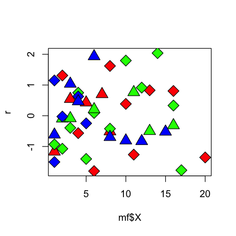

```r
r = rstandard(model_EM33)
mf = model.frame(model_EM33)
plot(mf$X, r, type='n')
for (i in 1:3) {
    for (j in 0:1) {
        subset <- as.logical((mf$E == i) * (mf$M == j))
        points(mf$X[subset], r[subset], pch=symbols[j+1], bg=colors[i], cex=2)
    }
}
```

Let's make a final plot of the fitted values.

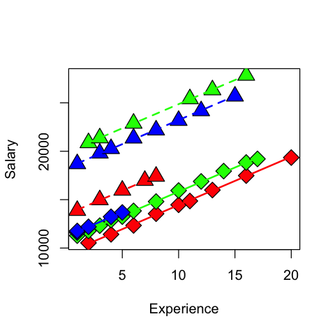

```r
salaryfinal.lm = lm(S ~ X + E * M, salary.table, subset=subs33)
mf = model.frame(salaryfinal.lm)
plot(mf$X, mf$S, type='n', xlab='Experience', ylab='Salary')
colors <- c('red', 'green', 'blue')
ltys <- c(2,3)
symbols <- c(23,24)
for (i in 1:3) {
    for (j in 0:1) {
        subset <- as.logical((mf$E == i) * (mf$M == j))
        points(mf$X[subset], mf$S[subset], pch=symbols[j+1], bg=colors[i], cex=2)
        lines(mf$X[subset], fitted(salaryfinal.lm)[subset], lwd=2, lty=ltys[j], col=colors[i])
    }
}
```

### Visualizing an interaction

From our first look at the data, the difference between Master's and PhD in the management group is different than in the non-management group. This is an interaction between the two qualitative variables *management,M* and *education,E*. We can visualize this by first removing the effect of experience, then plotting the means within each of the 6 groups using *interaction.plot*.

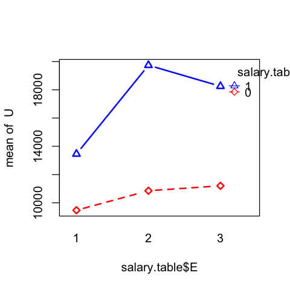

```r
U = salary.table$S - salary.table$X * model_EM$coef['X']
interaction.plot(salary.table$E, salary.table$M, U, type='b', col=c('red',
                'blue'), lwd=2, pch=c(23,24))
```

### Jobtest employment data (RABE)

[output not shown]

```r
url = 'http://stats191.stanford.edu/data/jobtest.table'
jobtest.table <- read.table(url, header=T)
jobtest.table$MINORITY <- factor(jobtest.table$MINORITY)
```

Since I will be making several plots, it will be easiest to attach `jobtest.table` though I will detach it later.

**These plots would be easier with `ggplot`.**

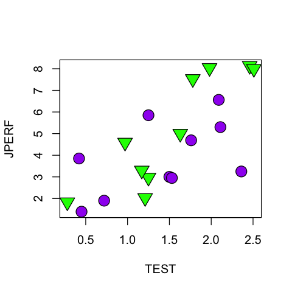

```r
attach(jobtest.table)
plot(TEST, JPERF, type='n')
points(TEST[(MINORITY == 0)], JPERF[(MINORITY == 0)], pch=21, cex=2,
       bg='purple')
points(TEST[(MINORITY == 1)], JPERF[(MINORITY == 1)], pch=25, cex=2, bg='green')
```

### General model

- In theory, there may be a linear relationship between $JPERF$ and $TEST$ but it could be different by group.
- Model: $$JPERF_i = \beta_0 + \beta_1 TEST_i + \beta_2 MINORITY_i + \beta_3 MINORITY_i * TEST_i + \varepsilon_i.$$
- Regression functions: $$ Y_i = \begin{cases} \beta_0 + \beta_1 TEST_i + \varepsilon_i & \text{if $MINORITY_i$=0} \\ (\beta_0 + \beta_2) + (\beta_1 + \beta_3) TEST_i + \varepsilon_i & \text{if $MINORITY_i=1$.} \\ \end{cases} $$

### Our first model: ($\beta_2=\beta_3=0$)

This has no effect for `MINORITY`.

```r
jobtest.lm1 <- lm(JPERF ~ TEST, jobtest.table)
print(summary(jobtest.lm1))
```

```
Call:
lm(formula = JPERF ~ TEST, data = jobtest.table)

Residuals:
    Min      1Q  Median      3Q     Max
-3.3558 -0.8798 -0.1897  1.2735  2.3312

Coefficients:
            Estimate Std. Error t value Pr(>|t|)
(Intercept)   1.0350     0.8680   1.192 0.248617
TEST          2.3605     0.5381   4.387 0.000356 ***
---
Signif. codes:  0 ‘***’ 0.001 ‘**’ 0.01 ‘*’ 0.05 ‘.’ 0.1 ‘ ’ 1

Residual standard error: 1.591 on 18 degrees of freedom
Multiple R-squared:  0.5167,	Adjusted R-squared:  0.4899
F-statistic: 19.25 on 1 and 18 DF,  p-value: 0.0003555
```

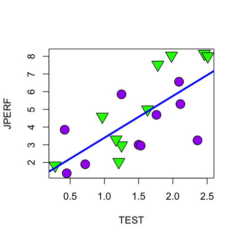

```r
plot(TEST, JPERF, type='n')
points(TEST[(MINORITY == 0)], JPERF[(MINORITY == 0)], pch=21, cex=2, bg='purple')
points(TEST[(MINORITY == 1)], JPERF[(MINORITY == 1)], pch=25, cex=2, bg='green')
abline(jobtest.lm1$coef, lwd=3, col='blue')
```

### Our second model ($\beta_3=0$)

This model allows for an effect of `MINORITY` but no interaction between `MINORITY` and `TEST`.

```r
jobtest.lm2 = lm(JPERF ~ TEST + MINORITY)
print(summary(jobtest.lm2))
```

```
Call:
lm(formula = JPERF ~ TEST + MINORITY)

Residuals:
    Min      1Q  Median      3Q     Max
-2.7872 -1.0370 -0.2095  0.9198  2.3645

Coefficients:
            Estimate Std. Error t value Pr(>|t|)
(Intercept)   0.6120     0.8870   0.690 0.499578
TEST          2.2988     0.5225   4.400 0.000391 ***
MINORITY1     1.0276     0.6909   1.487 0.155246
---
Signif. codes:  0 ‘***’ 0.001 ‘**’ 0.01 ‘*’ 0.05 ‘.’ 0.1 ‘ ’ 1

Residual standard error: 1.54 on 17 degrees of freedom
Multiple R-squared:  0.5724,	Adjusted R-squared:  0.5221
F-statistic: 11.38 on 2 and 17 DF,  p-value: 0.0007312
```

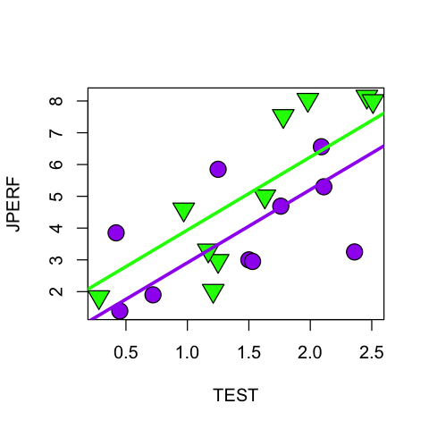

```r
plot(TEST, JPERF, type='n')
points(TEST[(MINORITY == 0)], JPERF[(MINORITY == 0)], pch=21, cex=2, bg='purple')
points(TEST[(MINORITY == 1)], JPERF[(MINORITY == 1)], pch=25, cex=2, bg='green')
abline(jobtest.lm2$coef['(Intercept)'], jobtest.lm2$coef['TEST'], lwd=3, col='purple')
abline(jobtest.lm2$coef['(Intercept)'] + jobtest.lm2$coef['MINORITY1'], jobtest.lm2$coef['TEST'], lwd=3, col='green')
```

### Our third model $(\beta_2=0)$:

This model includes an interaction between `TEST` and `MINORITY`. These lines have the same intercept but possibly different slopes within the `MINORITY` groups.

```r
jobtest.lm3 = lm(JPERF ~ TEST + TEST:MINORITY, jobtest.table)
summary(jobtest.lm3)
```

```
Call:
lm(formula = JPERF ~ TEST + TEST:MINORITY, data = jobtest.table)

Residuals:
     Min       1Q   Median       3Q      Max
-2.41100 -0.88871 -0.03359  0.97720  2.44440

Coefficients:
               Estimate Std. Error t value Pr(>|t|)
(Intercept)      1.1211     0.7804   1.437  0.16900
TEST             1.8276     0.5356   3.412  0.00332 **
TEST:MINORITY1   0.9161     0.3972   2.306  0.03395 *
---
Signif. codes:  0 ‘***’ 0.001 ‘**’ 0.01 ‘*’ 0.05 ‘.’ 0.1 ‘ ’ 1

Residual standard error: 1.429 on 17 degrees of freedom
Multiple R-squared:  0.6319,	Adjusted R-squared:  0.5886
F-statistic: 14.59 on 2 and 17 DF,  p-value: 0.0002045
```

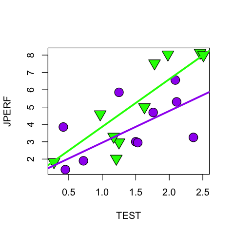

```r
plot(TEST, JPERF, type='n')
points(TEST[(MINORITY == 0)], JPERF[(MINORITY == 0)], pch=21, cex=2, bg='purple')
points(TEST[(MINORITY == 1)], JPERF[(MINORITY == 1)], pch=25, cex=2, bg='green')
abline(jobtest.lm3$coef['(Intercept)'], jobtest.lm3$coef['TEST'], lwd=3, col='purple')
abline(jobtest.lm3$coef['(Intercept)'], jobtest.lm3$coef['TEST'] + jobtest.lm3$coef['TEST:MINORITY1'], lwd=3, col='green')
```

Let's look at our design matrix again to be sure we understand which model was fit.

```r
head(model.matrix(jobtest.lm3))
```

|  | (Intercept) | TEST | TEST:MINORITY1 |
| --- | --- | --- | --- |
| 1 | 1 | 0.28 | 0.28 |
| 2 | 1 | 0.97 | 0.97 |
| 3 | 1 | 1.25 | 1.25 |
| 4 | 1 | 2.46 | 2.46 |
| 5 | 1 | 2.51 | 2.51 |
| 6 | 1 | 1.17 | 1.17 |

### Our final model: no constraints

This model allows for different intercepts and different slopes.

```r
jobtest.lm4 = lm(JPERF ~ TEST * MINORITY, jobtest.table)
summary(jobtest.lm4)
```

```
Call:
lm(formula = JPERF ~ TEST * MINORITY, data = jobtest.table)

Residuals:
    Min      1Q  Median      3Q     Max
-2.0734 -1.0594 -0.2548  1.2830  2.1980

Coefficients:
               Estimate Std. Error t value Pr(>|t|)
(Intercept)      2.0103     1.0501   1.914   0.0736 .
TEST             1.3134     0.6704   1.959   0.0677 .
MINORITY1       -1.9132     1.5403  -1.242   0.2321
TEST:MINORITY1   1.9975     0.9544   2.093   0.0527 .
---
Signif. codes:  0 ‘***’ 0.001 ‘**’ 0.01 ‘*’ 0.05 ‘.’ 0.1 ‘ ’ 1

Residual standard error: 1.407 on 16 degrees of freedom
Multiple R-squared:  0.6643,	Adjusted R-squared:  0.6013
F-statistic: 10.55 on 3 and 16 DF,  p-value: 0.0004511
```

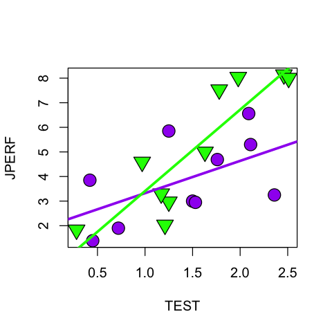

```r
plot(TEST, JPERF, type='n')
points(TEST[(MINORITY == 0)], JPERF[(MINORITY == 0)], pch=21, cex=2, bg='purple')
points(TEST[(MINORITY == 1)], JPERF[(MINORITY == 1)], pch=25, cex=2, bg='green')
abline(jobtest.lm4$coef['(Intercept)'], jobtest.lm4$coef['TEST'], lwd=3, col='purple')
abline(jobtest.lm4$coef['(Intercept)'] + jobtest.lm4$coef['MINORITY1'],
      jobtest.lm4$coef['TEST'] + jobtest.lm4$coef['TEST:MINORITY1'], lwd=3, col='green')
```

The expression `TEST*MINORITY` is shorthand for `TEST + MINORITY + TEST:MINORITY`.

```r
head(model.matrix(jobtest.lm4))
```

|  | (Intercept) | TEST | MINORITY1 | TEST:MINORITY1 |
| --- | --- | --- | --- | --- |
| 1 | 1 | 0.28 | 1 | 0.28 |
| 2 | 1 | 0.97 | 1 | 0.97 |
| 3 | 1 | 1.25 | 1 | 1.25 |
| 4 | 1 | 2.46 | 1 | 2.46 |
| 5 | 1 | 2.51 | 1 | 2.51 |
| 6 | 1 | 1.17 | 1 | 1.17 |

### Comparing models

Is there any effect of MINORITY on slope or intercept?

```r
anova(jobtest.lm1, jobtest.lm4) # ~ TEST to ~ TEST * MINORITY
```

| Res.Df | RSS | Df | Sum of Sq | F | Pr(>F) |
| --- | --- | --- | --- | --- | --- |
| 18 | 45.56830 | NA | NA | NA | NA |
| 16 | 31.65547 | 2 | 13.91282 | 3.516061 | 0.05423606 |

Is there any effect of MINORITY on intercept? (Assuming we have accepted the hypothesis that the slope is the same within each group).

```r
anova(jobtest.lm1, jobtest.lm2) # ~ TEST to ~ TEST + MINORITY
```

| Res.Df | RSS | Df | Sum of Sq | F | Pr(>F) |
| --- | --- | --- | --- | --- | --- |
| 18 | 45.56830 | NA | NA | NA | NA |
| 17 | 40.32155 | 1 | 5.246751 | 2.212087 | 0.1552463 |

We could also have allowed for the possiblity that the slope is different within each group and still check for a different intercept.

```r
anova(jobtest.lm3, jobtest.lm4) # ~ TEST + TEST:MINORITY to
                                # ~ TEST * MINORITY
```

| Res.Df | RSS | Df | Sum of Sq | F | Pr(>F) |
| --- | --- | --- | --- | --- | --- |
| 17 | 34.70765 | NA | NA | NA | NA |
| 16 | 31.65547 | 1 | 3.05218 | 1.542699 | 0.2321149 |

Is there any effect of `MINORITY` on slope? (Assuming we have accepted the hypothesis that the intercept is the same within each group).

```r
anova(jobtest.lm1, jobtest.lm3) # ~ TEST vs. ~ TEST + TEST:MINORITY
```

| Res.Df | RSS | Df | Sum of Sq | F | Pr(>F) |
| --- | --- | --- | --- | --- | --- |
| 18 | 45.56830 | NA | NA | NA | NA |
| 17 | 34.70765 | 1 | 10.86064 | 5.319603 | 0.03394851 |

Again, we could have allowed for the possibility that the intercept is different within each group.

```r
anova(jobtest.lm2, jobtest.lm4) # ~ TEST + MINORITY vs.
                                # ~ TEST * MINORITY
```

| Res.Df | RSS | Df | Sum of Sq | F | Pr(>F) |
| --- | --- | --- | --- | --- | --- |
| 17 | 40.32155 | NA | NA | NA | NA |
| 16 | 31.65547 | 1 | 8.666073 | 4.380196 | 0.05265012 |

In summary, without taking the several tests into account here, there does seem to be some evidence that the slope is different within the two groups.

```r
detach(jobtest.table)
```

## Model selection

Already with this simple dataset (simpler than the IT salary data) we have 4 competing models. How are we going to arrive at a final model?

This highlights the need for *model selection*. We will come to this topic shortly.